# Peak Heart rate of a human Related with Cholesterol Level and Sex?

Nafis Ahmed Munim

May 2 , 2021

## Background and Significance

Does having an increased Cholesterol Level which is Triglyceride and HDL Cholesterol affects the Peak Heart rate of a person regardless which gender the person belongs to? Moreover, Does Peak Heart Rate in Male and Female who tend to have the same Cholesterol level affects the Peak Heart Rate of a Human Being? As Cardio Vascular Disease is a very rising question to the world right now. Doctors and Medical Scientists try to find a possible relation between the Cholesterol Level and Gender with the Peak Heart rate which eventually is related to Cardio Vascular Disease and Heart Attack.

However, Prior Researches find the affect of Cholesterol in Chronic Heart Failure and Heart Failure. Mehdi H. Shishehbor, DO1, Byron J. Hoogwerf, MD2 and Michael S. Lauer, MD3(2004 April) found that , “HRR is associated with triglyceride–to–HDL cholesterol ratio and identifies patients with insulin resistance who are at increased risk of death.” J Am Coll Cardiol at 2003 Dec worked with 303 unselected patients to find the relation between Cholesterol and Coronary Heart Disease, Chronic Heart Failure. A study conducted in April 2020 by "Philipp Birnbaumer,1 Heimo Traninger,2 Andrea Borenich,3 Markus Falgenhauer,4 Robert Modre-Osprian,4 Hanns Harpf,2 and Peter Hofmann1,*" shows that “Changes in HRPC’s were affected by sex and performance, where women generally and subjects with higher performance presented less atypical HRPC’s even at older age.” In this Paper, we investigate the relation between the Cholesterol and Peak Heart Rate and Gender using bootstrapping and confidence interval. We also investigate whether there is a relation in the peak heart rate achieved and the gender.

## Data

Using Kaggle.com, we obtained data on 303 Patients, who were observed to find out any heart attack risk. We considered the Quantitative varibales Cholesterol Level mg/dl and Peak Heart rate. We also considered the categorical variable Sex. We had data for all the observations and no values were missing in the data. The number of Males in the observations were 207 and the number of female was 96. The Table below shows the Mean and the Standard Deviation of the two quantitative Variables Peak Heart rate and Cholesterol Level.

Data summary

| Name | Heartanalysis |
| --- | --- |
| Number of rows | 303 |
| Number of columns | 3 |
| _______________________ |  |
| Column type frequency: |  |
| factor | 1 |
| numeric | 2 |
| ________________________ |  |
| Group variables | None |

**Variable type: factor**

| skim_variable | n_missing | complete_rate | ordered | n_unique | top_counts |
| --- | --- | --- | --- | --- | --- |
| sex | 0 | 1 | FALSE | 2 | Mal: 207, Fem: 96 |

**Variable type: numeric**

Summary Statistics

| skim_variable | n_missing | complete_rate | mean | sd | p0 | p25 | p50 | p75 | p100 | hist |
| --- | --- | --- | --- | --- | --- | --- | --- | --- | --- | --- |
| chol | 0 | 1 | 246.26 | 51.83 | 126 | 211.0 | 240 | 274.5 | 564 | ▃▇▂▁▁ |
| thalachh | 0 | 1 | 149.65 | 22.91 | 71 | 133.5 | 153 | 166.0 | 202 | ▁▂▅▇▂ |

| sex | Mean_Cholesterol | StDev_Cholesterol | Mean_Peakheartrate | StDev_Peakheartrate |
| --- | --- | --- | --- | --- |
| Female | 261.3021 | 65.08895 | 151.1250 | 20.04797 |
| Male | 239.2899 | 42.78239 | 148.9614 | 24.13088 |

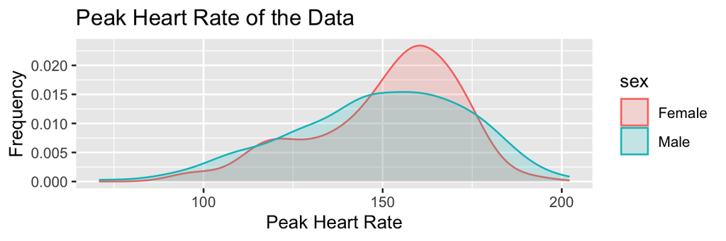

Distribution of Peak Heart rate

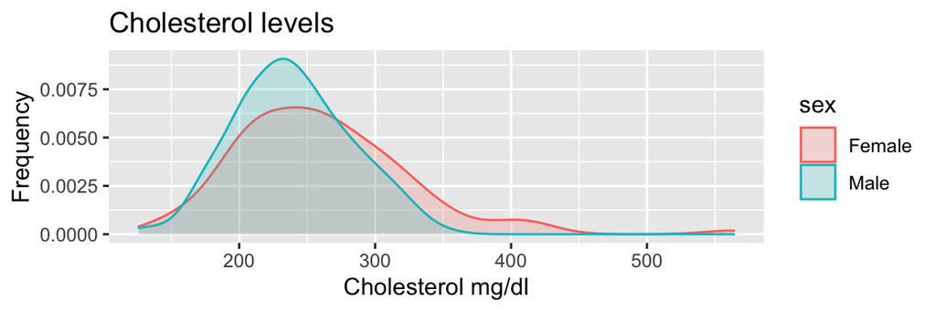

Distribution of CHOLESTEROL LEVELS

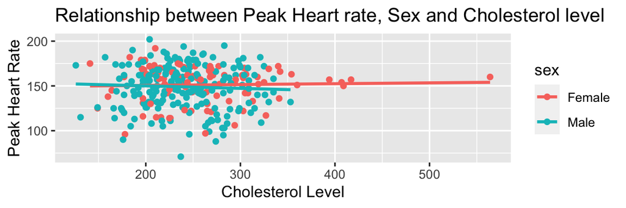

Relationship between Peak Heart rate and Cholesterol for each Sex